# apparatus

## venturi apparatus

We have a venturi apparatus that allows water to flow through pipes of various thickness. Explain why the water level at each measurement pipe is different. Does the difference increase as the flow rate increases? Is there a power law?

## How it works

venturi apparatus is used to measure the flow rate of a fluid in a pipe. It works on the principle of Bernoulli's equation. The apparatus consists of a pipe with a constriction in the middle. The constriction is called the venturi. When the fluid flows through the venturi steadily, the flux at anywhere in the pipe is the same, and because the flux is the product of the area and the velocity, the velocity of the fluid increases as the area decreases. According to Bernoulli's equation, the pressure of the fluid decreases as the velocity increases. Therefore, the pressure at the venturi is lower than the pressure at the entrance of the pipe, thus the water level at the venturi is lower than the water level at the entrance of the pipe.

## equation

Consider two location in the pipe, the Bernoulli's equation is given by: $$P_1/\rho + v_1^2/2 = P_2/\rho + v_2^2/2$$ (we ignored the height difference between the two locations)

The pressure is measured by the water level, $$P = \rho g h$$ so we can write: $$ g h_1 + v_1^2/2 = g h_2 + v_2^2/2$$

The velocity is measured by the ratio of the flux to the area, $$v = Q/A$$ where $Q$ is the flux, $A$ is the area

```python
import numpy as np
import pandas as pd
import matplotlib.pyplot as plt
```

```python
# all in SI units
# 1 liter
volume = 10**-3
g = 9.8
diameter = np.array([25, 14.6, 12.4, 11.3, 10.6, 10]) * 10**-3
surface = np.pi * (diameter/2)**2
print(f"surface = {surface} (m^2)")
```

```
surface = [4.90873852e-04 1.67415473e-04 1.20762822e-04 1.00287491e-04
 8.82473376e-05 7.85398163e-05] (m^2)
```

### experiment 1

[figure not shown]

in the first experiment, we had maximum flux, which is measured by the time taken to fill a 1-liter bottle. The time is measured from the video.

```python
time1 = 5.8 # seconds
```

```python
# the flux
flux1 = volume/time1
```

from the picture above, we only have the water level for the first three pipes, so we can only measure the pressure for the first three pipes.

```python
height1 = np.array([115, 62, 17]) * 10**-3
```

their corresponding velocities

```python
velocity1 = flux1/surface[:3]
print(f"velocity = {velocity1} (m/s)")
```

```
velocity = [0.3512385  1.02985579 1.4277059 ] (m/s)
```

now we can check if the bernoulli's equation holds

```python
bernoulli1 = g * height1 + velocity1**2/2
print(f"bernoulli = {bernoulli1} (m^2/s^2)")
bernoulli1
```

```
bernoulli = [1.18868424 1.13790147 1.18577207] (m^2/s^2)
```

```
array([1.18868424, 1.13790147, 1.18577207])
```

### experiment 2

[figure not shown]

```python
time2 = 6.9 # seconds
```

```python
# the flux
flux2 = volume/time2
```

```python
height2 = np.array([275, 232, 197, 159, 116, 58]) * 10**-3
```

their corresponding velocities

```python
velocity2 = flux2/surface
print(f"velocity = {velocity2} (m/s)")
```

```
velocity = [0.29524395 0.86567588 1.20010061 1.44512076 1.64228792 1.8452747 ] (m/s)
```

check if the bernoulli's equation holds

```python
bernoulli2 = g * height2 + velocity2**2/2
print(f"bernoulli = {bernoulli2} (m^2/s^2)")
bernoulli2
```

```
bernoulli = [2.7385845  2.64829736 2.65072074 2.60238701 2.4853548  2.27091936] (m^2/s^2)
```

```
array([2.7385845 , 2.64829736, 2.65072074, 2.60238701, 2.4853548 ,
       2.27091936])
```

### experiment 3

[figure not shown]

```python
time3 = (8.6-2) # seconds
print(f"time3 = {time3} (s)")
```

```
time3 = 6.6 (s)
```

```python
# the flux
flux3 = volume/time3
```

```python
height3 = np.array([150, 107, 71.5, 33]) * 10**-3
```

```python
velocity3 = flux3/surface[:4]
```

check if the bernoulli's equation holds

```python
bernoulli3 = g * height3 + velocity3**2/2
print(f"bernoulli = {bernoulli3} (m^2/s^2)")
bernoulli3
```

```
bernoulli = [1.51763677 1.45813493 1.48777412 1.46467051] (m^2/s^2)
```

```
array([1.51763677, 1.45813493, 1.48777412, 1.46467051])
```

### Does the difference increase as the flow rate increases? Is there a power law?

the difference between water levels is proportional to the velocity squared, thus proportional to the flux squared. Let's check if the difference between the water levels is proportional to the flux squared.

```python
h_diff_to_fsquare1 = (height1[0] - height1) / (flux1 ** 2)
h_diff_to_fsquare1 = np.append(h_diff_to_fsquare1, [np.nan]*3)
h_diff_to_fsquare2 = (height2[0] - height2) / (flux2 ** 2)
h_diff_to_fsquare3 = (height3[0] - height3) / (flux3 ** 2)
h_diff_to_fsquare3 = np.append(h_diff_to_fsquare3, [np.nan]*2)
h_diff_to_fsquare3
```

```
array([      0., 1873080., 3419460., 5096520.,      nan,      nan])
```

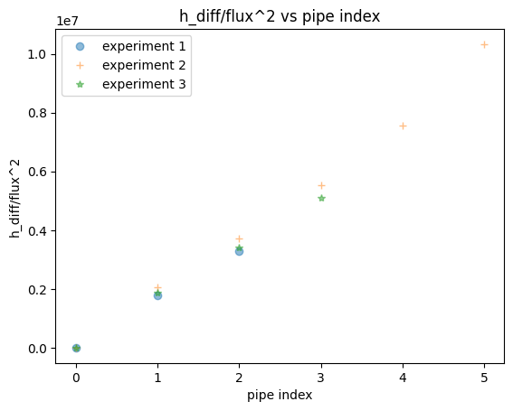

```python
plt.figure()
plt.plot(h_diff_to_fsquare1, 'o', label='experiment 1', alpha=0.5)
plt.plot(h_diff_to_fsquare2, '+', label='experiment 2', alpha=0.5)
plt.plot(h_diff_to_fsquare3, '*', label='experiment 3', alpha=0.5)
plt.xlabel('pipe index')
plt.ylabel('h_diff/flux^2')
plt.title('h_diff/flux^2 vs pipe index')
plt.legend()
```

### how does the bernoulli's equation constant change with the flux?

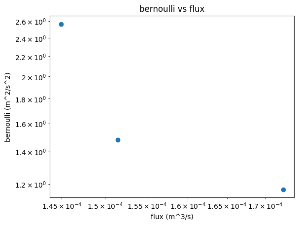

```python
bernoullis = np.array([np.mean(bernoulli1), np.mean(bernoulli2), np.mean(bernoulli3)])
fluxs = np.array([flux1, flux2, flux3])
plt.plot(fluxs, bernoullis, 'o')

plt.xscale('log')
plt.yscale('log')
plt.title('bernoulli vs flux')
plt.xlabel('flux (m^3/s)')
plt.ylabel('bernoulli (m^2/s^2)')
```